# stranger weirds methods

## knn

```
## *** weird method k-Nearest Neighbour
## knn based on function knn.dist [FNN]
## Metric: Positive numeric value (distance) sorted in decreasing order.
```

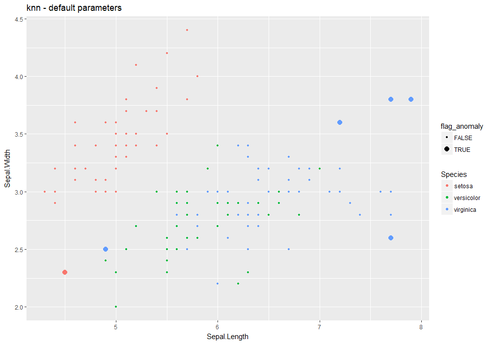

```r
iris %>%
  lucky_odds(n.anom=6, analysis.drop="Species", weird="knn") %>%
  anoplot(title="knn - default parameters")
```

Default values for `knn` parameters – see `?knn`:

- k=10
- … other parameters to be passed to `knn` (prob, algorihtm)

Extra parameters used in `stranger` for this weird:

- simplify=“mean”: name of a function to be used to aggregate neirest neighbours distances. User may use other existing base funcions (for instance `median`) but can also use his own function – name to be supplied as string.

Default naming convention for generated metric based on *k* and *simplify*.

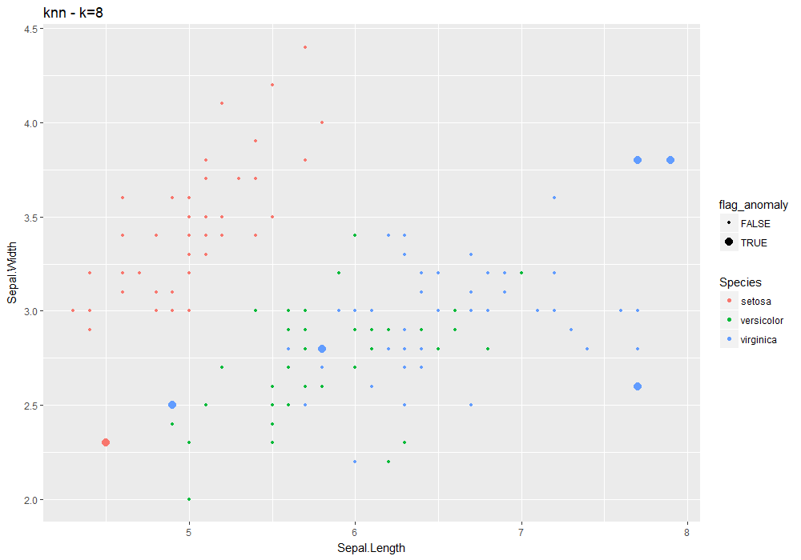

```r
iris %>%
  lucky_odds(n.anom=6, analysis.drop="Species",weird="knn",k=8) %>%
  anoplot(title="knn - k=8")
```

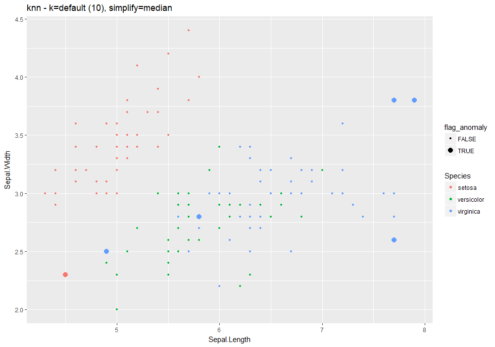

```r
iris %>%
  lucky_odds(n.anom=6, analysis.drop="Species",weird="knn",simplify="median") %>%
  anoplot(title="knn - k=default (10), simplify=median")
```

## lof

```
## *** weird method Local Outlier Factor
## lof based on function lof [dbscan]
## Metric: Positive numeric value (local outlier factors) sorted in decreasing order.
```

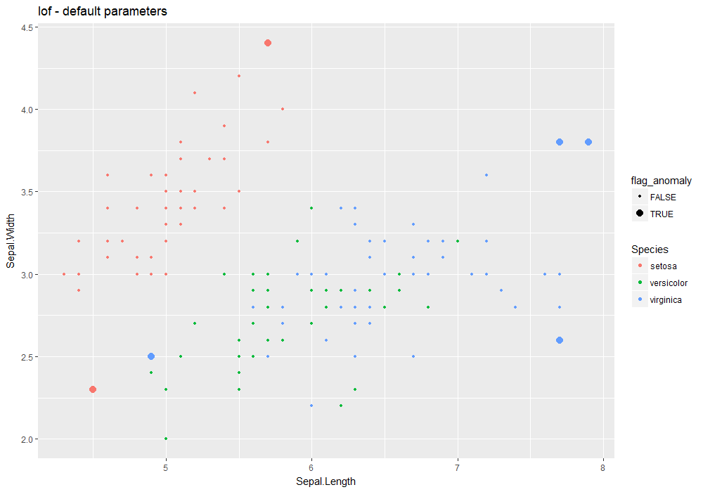

```r
iris %>%
  lucky_odds(n.anom=6, analysis.drop="Species", weird="lof") %>%
  anoplot(title="lof - default parameters")
```

Default values for `lof` parameters – see `?lof`:

- k=10
- … other parameters to be passed to `kNN` from `dbscan` package (search, bucketSize…).

Extra parameters used in `stranger` for this weird: none.

Default naming convention for generated metric based on *k*.

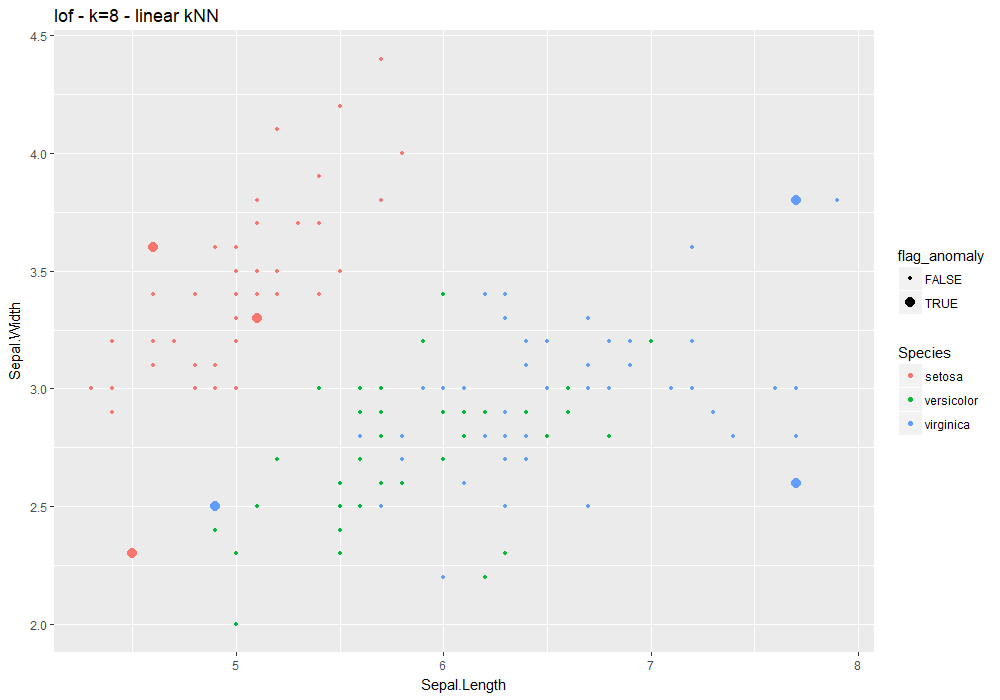

```r
iris %>%
  lucky_odds(n.anom=6, analysis.drop="Species",weird="lof",k=8, search="linear") %>%
  anoplot(title="lof - k=8 - linear kNN")
```

From `lof` help:

LOF compares the local density of an point to the local densities of its neighbors. Points that have a substantially lower density than their neighbors are considered outliers. A LOF score of approximately 1 indicates that density around the point is comparable to its neighbors. Scores significantly larger than 1 indicate outliers.

## mahalanobis

```
## *** weird method Mahalanobis distance
## mahalanobis based on function mahalanobis [stats]
## Metric: Positive numeric value (distance) sorted in decreasing order.
```

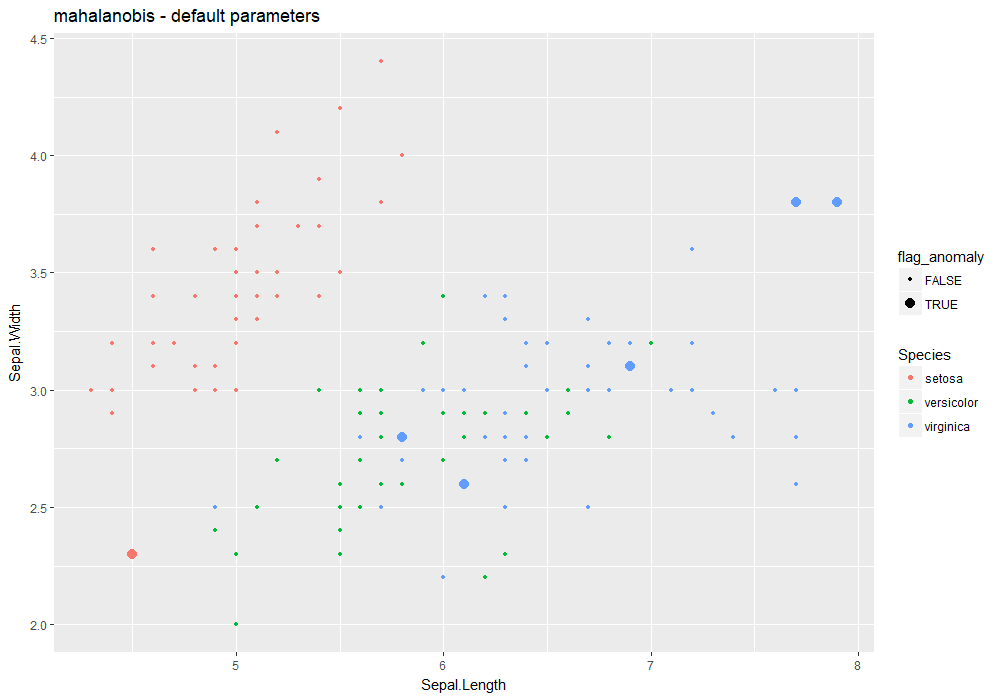

```r
iris %>%
  lucky_odds(n.anom=6, analysis.drop="Species", weird="mahalanobis") %>%
  anoplot(title="mahalanobis - default parameters")
```

No parameter available.

Default naming convention: mahalanobis.

## pcout

```
## *** weird method Semi-robust principal components > distances
## pcout based on function pcout [mvoutlier]
## Metric: Positive numeric value (distance) sorted in decreasing order.
```

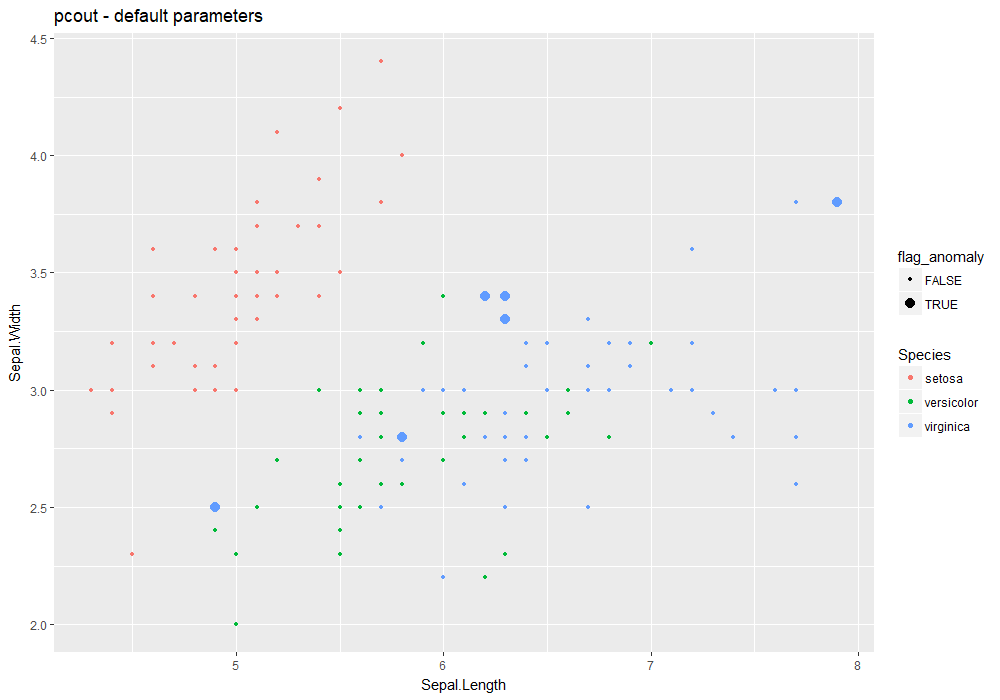

```r
iris %>%
  lucky_odds(n.anom=6, analysis.drop="Species", weird="pcout") %>%
  anoplot(title="pcout - default parameters")
```

Default values for `pcout` parameters – see `?pcout`:

- explvar=0.99
- crit.M1=1/3
- crit.M2=1/4
- crit.c2=0.99
- crit.cs=0.25
- outbound=0.25
- … not used here.

Extra parameters used in `stranger` for this weird: none.

Default naming convention for generated metric based on *explvar*.

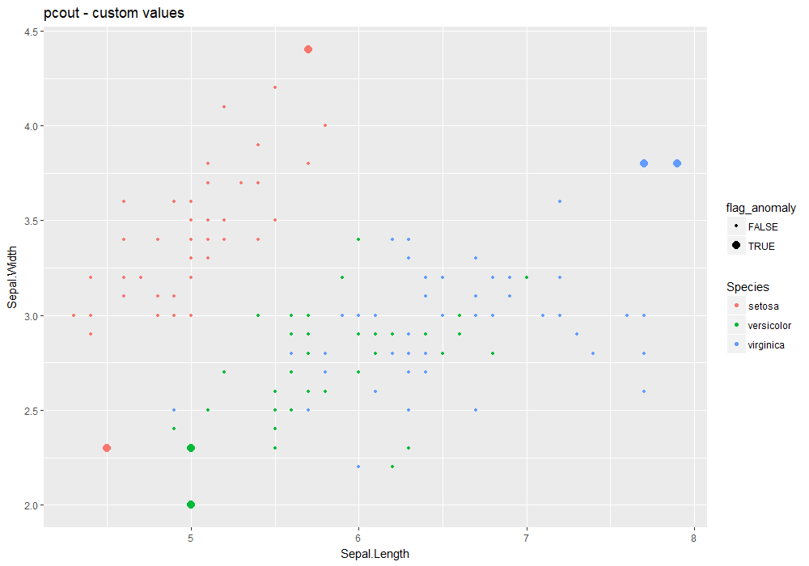

```r
iris %>%
  lucky_odds(n.anom=6, analysis.drop="Species",weird="pcout", explvar=0.8, crit.Ml=1, crit.cl=3) %>%
  anoplot(title="pcout - custom values")
```

From `pcout` help:

Based on the robustly sphered data, semi-robust principal components are computed which are needed for determining distances for each observation. Separate weights for location and scatter outliers are computed based on these distances. The combined weights are used for outlier identification.

## randomforest

```
## *** weird method randomforest outlier metric
## randomforest based on function randomForest [randomForest]
## Metric: Positive numeric value (distance) sorted in decreasing order.
```

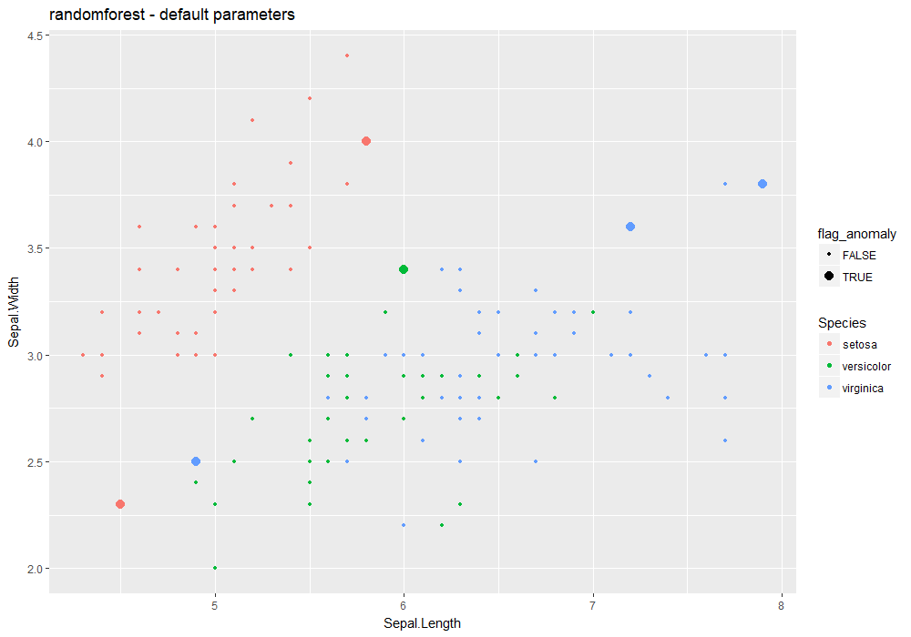

```r
iris %>%
  lucky_odds(n.anom=6, analysis.drop="Species", weird="randomforest") %>%
  anoplot(title="randomforest - default parameters")
```

Default values for `randomforest` parameters – see `?randomforest`:

- ntree=500
- mtry=sqrt(ncol(data))
- replace=TRUE
- … other parameters to be used in `randomForest`

Extra parameters used in `stranger` for this weird: none.

Default naming convention for generated metric based on *ntree* and *mtry*.

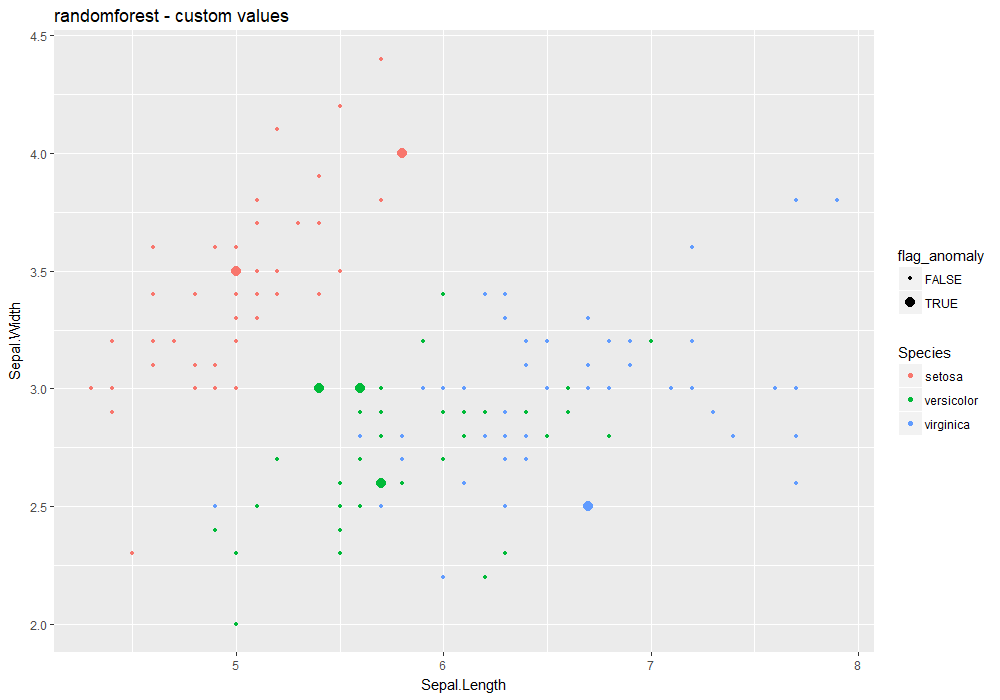

```r
iris %>%
  lucky_odds(n.anom=6, analysis.drop="Species",weird="randomforest", explvar=0.8, ntree=10,mtry=2) %>%
  anoplot(title="randomforest - custom values")
```

## To go further

Logical next step is to look at how to work with *weirds* methods: manipulate, work with metrics (aggregation and stacking), derive anomalies. For this, read vignette Working with weirds